# Préparation des données

Paul Bourcier & Antoine Le Doeuff

Novembre 2023

# 1 Script de préparation des données DVF

## 1.1 Importation des données et filtrage selon la zone d’étude et les attributs retenus

Charger les librairies et paramétrer l’affichage des nombres

```r
library(data.table)
library(tidyverse)
library(happign)
library(sf)
library(PupillometryR) # pour le boxplot
library(gridExtra)
library(grid)
library(deeptime)

options(scipen = 999)
```

## 1.2 Importation et assemblage des fichiers

```r
start_time <- Sys.time()

# Initialiser un data.table vide pour l'assemblage dans lequel seront
# assemblés les fichiers importés
assemblage <- data.table()

# pour créer une liste avec le nom des fichiers csv contenus dans le
# répertoire de travail
files_names <- list.files("data/", pattern = "full.*csv")

# démarrage de l'import et de la sélection des données par année
for (i in seq_along(files_names)) {
  # Utilisez fread pour lire les fichiers CSV
  temp <- fread(paste0("data/", files_names[i]), encoding = "UTF-8")

  # Filtrez et sélectionnez les données
  temp <- temp %>%
    filter(
      nature_mutation == "Vente",
      type_local == "Maison" | type_local == "Appartement"
    )

  # Sélectionnez les colonnes
  temp <- temp[, .(
    id = id_mutation,
    disposition = numero_disposition,
    parcelle = id_parcelle,
    date = date_mutation,
    nature = nature_mutation,
    codecommune = code_commune,
    departement = code_departement,
    type = type_local,
    surface = surface_reelle_bati,
    piece = nombre_pieces_principales,
    prix = valeur_fonciere,
    latitude,
    longitude
  )]

  # Remplacez les cellules vides par des NA
  temp[temp == ""] <- NA

  # Empilez les fichiers annuels
  assemblage <- rbindlist(list(assemblage, temp))
}

# Supprimer les lignes contenant des NA
assemblage <- assemblage[complete.cases(assemblage)]

# Pour supprimer les objets après les avoir importés et ajoutés
# à l’objet consolidé contenant toutes les années
rm(files_names, temp, i)

end_time <- Sys.time()
time_taken <- end_time - start_time
time_taken
```

```
Time difference of 3.238497 mins
```

## 1.3 Sélection spatiale des ventes

On s’intéresse à l’EPCI de la Rochelle. Les ventes qui ont eu lieu dans le département de la Charente-Maritime sont sélectionnées.

```r
dvf_charent_all <- assemblage %>%
  filter(departement == "17")
```

On charge les communes du département de la Charente-Maritime au moyen du package `happign`.

```r
cog <- happign::get_wfs(
  x = NULL,
  apikey = "administratif",
  layer = "ADMINEXPRESS-COG-CARTO.LATEST:commune",
  ecql_filter = "insee_dep = '17'"
)
```

```r
cog <- cog %>%
  rename("codecommune" = insee_com) %>%
  st_transform(2154)
```

On fusionne les ventes et les communes.

```r
merge_vente_charente <- merge(
  dvf_charent_all,
  select(as_tibble(cog), -geometry),
  by = "codecommune"
)
```

### 1.3.1 Sélection des communes de la CA de La Rochelle et alentours

Pour limiter l’effet de bord, nous réalisons la préparation du jeu de données sur l’EPCI ainsi que sur les communes lui étant adjacentes.

```r
epci_lr <- cog %>%
  filter(siren_epci == "241700434")

# Sélection des communes attenantes
cog$inter <- st_intersects(cog, sf::st_union(epci_lr), sparse = FALSE)
roch_com_juxt <- cog %>% filter(inter == "TRUE")
```

Visualisation des communes sélectionnées.

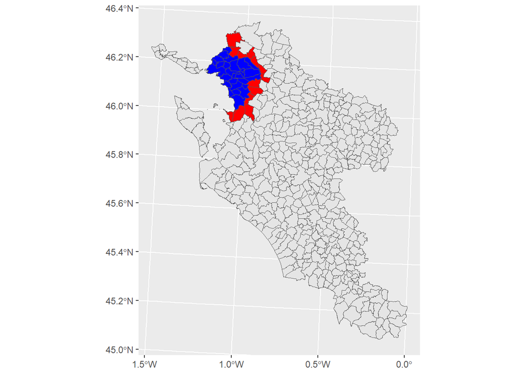

```r
ggplot() +
  geom_sf(data = cog) +
  geom_sf(data = roch_com_juxt, fill = "Red") +
  geom_sf(data = epci_lr, fill = "Blue")
```

On joint les ventes aux communes sélectionnées.

```r
merge_vente_roch <- right_join(
  merge_vente_charente,
  select(as_tibble(roch_com_juxt), id, nom, codecommune, -geometry),
  by = "codecommune"
)
```

31353 ventes sont identifiées.

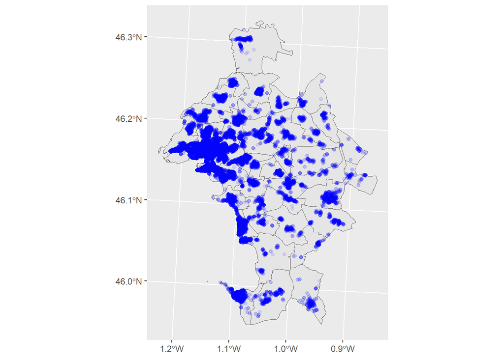

```r
merge_vente_roch_sf <- st_as_sf(
  merge_vente_roch,
  coords = c("longitude", "latitude"), crs = 4326
)
merge_vente_roch_sf <- st_transform(merge_vente_roch_sf, crs = 2154)

# Visualisation des résultats
ggplot() +
  geom_sf(data = roch_com_juxt) +
  geom_sf(data = merge_vente_roch_sf, color = "Blue", alpha = 0.1)
```

## 1.4 Nettoyage des données

On commence par supprimer les valeurs `NULL`.

```r
# suppression des nulls
merge_vente_roch <- merge_vente_roch %>% na.omit()
```

### 1.4.1 Détection et suppression des doublons et des mutations multiventes

```r
# pour vérifier s'il y a des doublons (lignes partageant le même id,
# le même prix et la même surface)
any(duplicated(
  paste0(merge_vente_roch$id, merge_vente_roch$prix, merge_vente_roch$surface)
))
```

```
[1] TRUE
```

```r
unique <- merge_vente_roch %>% distinct(id.x, prix, surface)
nbunique <- unique %>%
  group_by(id.x) %>%
  summarise(nb = n())
merge_vente_roch_uni <- nbunique %>% filter(nb == 1)
```

Il y a 1215 mutations complexes, soit 4.42 % de l’échantillon. On ne garde que les mutations monoventes.

```r
merge_unique <- merge_vente_roch %>%
  distinct(id.x, prix, surface, .keep_all = TRUE) %>%
  group_by(id.x) %>%
  filter(n() == 1)
```

### 1.4.2 Sélection des variables

```r
vente_roch <- merge_unique %>%
  select(
    id.x,
    date,
    type,
    nature,
    codecommune,
    prix,
    surface,
    piece,
    siren_epci,
    latitude,
    longitude
  ) %>%
  rename("id_vente" = "id.x")
```

### 1.4.3 Filtrage des données

#### 1.4.3.1 Identification des seuils

Création d’un graphique montrant la distribution statistique des prix et des surfaces selon le type de bien. Les outliers sont identifiés par la méthode des percentiles (0.01 pct et 0.99 pct) ainsi que par la méthode du boxplot (*c.f.* équations ci-dessous)

$$T_u = Q_3 + 1,5 \times IQR\\
T_b = Q_1 - 1,5 \times IQR$$

Où $T_u$ est le seuil supérieur et $T_b$ est le seuil inférieur.

```r
types <- c("prix", "surface")
plots <- list()
list_lim <- list()
for (tp in types) {
  wh_pct <- vente_roch %>%
    drop_na(.data[[tp]]) %>%
    filter(.data[[tp]] > 0) %>%
    group_by(type) %>%
    summarise(
      wh_hight = quantile(.data[[tp]], 0.75) + 1.5 * IQR(.data[[tp]]),
      wh_low = quantile(.data[[tp]], 0.25) - 1.5 * IQR(.data[[tp]]),
      pct_low = quantile(.data[[tp]], 0.01),
      pct_high = quantile(.data[[tp]], 0.99)
    )

  print(wh_pct)
  list_lim[[tp]] <- wh_pct

  plot <- vente_roch %>%
    select(.data[[tp]], type) %>%
    ggplot(aes(x = type, y = .data[[tp]], fill = type)) +
    theme_minimal() +
    PupillometryR::geom_flat_violin(
      position = position_nudge(x = .2),
      alpha = .4,
      show.legend = FALSE
    ) +
    geom_point(
      color = "#edf5fd",
      position = position_jitter(w = .15),
      size = 1,
      show.legend = TRUE
    ) +
    geom_boxplot(
      width = .25,
      outlier.shape = NA,
      alpha = 0.5
    ) +
    geom_segment(
      x = 0.75,
      xend = 1.25,
      y = as.numeric(wh_pct[wh_pct$type == "Appartement", "pct_high"]),
      yend = as.numeric(wh_pct[wh_pct$type == "Appartement", "pct_high"])
    ) +
    annotate(
      "text",
      x = 0.65,
      y = as.numeric(wh_pct[wh_pct$type == "Appartement", "pct_high"]),
      label = paste(round(as.numeric(wh_pct[wh_pct$type == "Appartement", "pct_high"]), 1))
    ) +
    geom_segment(
      x = 0.75,
      xend = 1.25,
      y = as.numeric(wh_pct[wh_pct$type == "Appartement", "pct_low"]),
      yend = as.numeric(wh_pct[wh_pct$type == "Appartement", "pct_low"])
    ) +
    annotate(
      "text",
      x = 0.65,
      y = as.numeric(wh_pct[wh_pct$type == "Appartement", "pct_low"]),
      label = paste(round(as.numeric(wh_pct[wh_pct$type == "Appartement", "pct_low"]), 1))
    ) +
    geom_segment(
      x = 1.75,
      xend = 2.25,
      y = as.numeric(wh_pct[wh_pct$type == "Maison", "pct_high"]),
      yend = as.numeric(wh_pct[wh_pct$type == "Maison", "pct_high"])
    ) +
    annotate(
      "text",
      x = 1.65,
      y = as.numeric(wh_pct[wh_pct$type == "Maison", "pct_high"]),
      label = paste(round(as.numeric(wh_pct[wh_pct$type == "Maison", "pct_high"]), 1))
    ) +
    geom_segment(
      x = 1.75,
      xend = 2.25,
      y = as.numeric(wh_pct[wh_pct$type == "Maison", "pct_low"]),
      yend = as.numeric(wh_pct[wh_pct$type == "Maison", "pct_low"])
    ) +
    annotate(
      "text",
      x = 1.65,
      y = as.numeric(wh_pct[wh_pct$type == "Maison", "pct_low"]),
      label = paste(round(as.numeric(wh_pct[wh_pct$type == "Maison", "pct_low"]), 1))
    )

  # Reformat label
  if (tp == "prix") {
    plot <- plot +
      scale_y_continuous(
        labels = function(y) y / 1E6,
        expand = c(0, 0)
      )
  } else {
    plot <- plot +
      scale_y_continuous(
        expand = c(0, 0)
      )
  }

  # Change coordinates
  tp_var <- rlang::sym(tp)
  plot <- plot +
    coord_trans_flip(
      y = scales::pseudo_log_trans()
    ) +
    labs(
      title = paste(tp),
      x = NULL,
      y = case_when(
        tp == "prix" ~ paste(tp, "(M€)"),
        tp == "surface" ~ paste(tp, "(m2)")
      )
    )

  plots[[tp]] <- plot
}
```

```
# A tibble: 2 × 5
  type        wh_hight wh_low pct_low pct_high
  <chr>          <dbl>  <dbl>   <dbl>    <dbl>
1 Appartement   360000 -40000  42516.   630000
2 Maison        568875 -45325  59148.   870000
# A tibble: 2 × 5
  type        wh_hight wh_low pct_low pct_high
  <chr>          <dbl>  <dbl>   <dbl>    <dbl>
1 Appartement     117   -19        17     127.
2 Maison          184.   12.5      31     241.
```

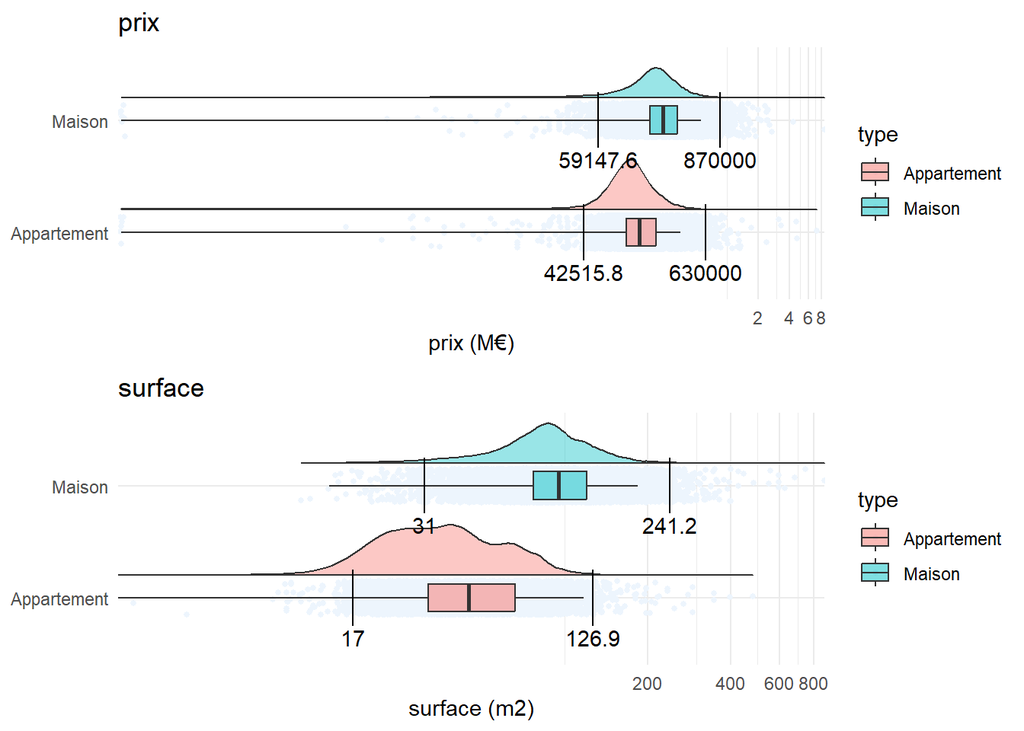

```r
grid.arrange(
  grobs = lapply(plots, ggplotGrob),
  nrow = 2, ncol = 1,
)
```

#### 1.4.3.2 Sélection des bornes de prix et de surface

```r
vente_roch_filter <- vente_roch %>%
  filter(
    case_when(
      type == "Appartement" ~ between(
        prix,
        as.numeric(list_lim$prix[1, "pct_low"]),
        as.numeric(list_lim$prix[1, "pct_high"])
      )
    ) |
      case_when(
        type == "Maison" ~ between(
          prix,
          as.numeric(list_lim$prix[2, "pct_low"]),
          as.numeric(list_lim$prix[2, "pct_high"])
        )
      ) |
      case_when(
        type == "Appartement" ~ between(
          surface,
          as.numeric(list_lim$surface[1, "pct_low"]),
          as.numeric(list_lim$surface[1, "pct_high"])
        )
      ) |
      case_when(
        type == "Maison" ~ between(
          surface,
          as.numeric(list_lim$surface[2, "pct_low"]),
          as.numeric(list_lim$surface[2, "pct_high"])
        )
      )
  )
```

116 individus ont été filtrées.

#### 1.4.3.3 Prix au mètre carré

```r
vente_roch_filter <- vente_roch_filter %>%
  mutate(prix_m2 = prix / surface)

lim_prix_m2 <- vente_roch_filter %>%
  drop_na(prix_m2) %>%
  filter(prix_m2 > 0) %>%
  group_by(type) %>%
  summarise(
    wh_hight = quantile(prix_m2, 0.75) + 1.5 * IQR(prix_m2),
    wh_low = quantile(prix_m2, 0.25) - 1.5 * IQR(prix_m2),
    pct_low = quantile(prix_m2, 0.01),
    pct_high = quantile(prix_m2, 0.99)
  )

print(lim_prix_m2)
```

```
# A tibble: 2 × 5
  type        wh_hight wh_low pct_low pct_high
  <chr>          <dbl>  <dbl>   <dbl>    <dbl>
1 Appartement    6770.   414.    979.    7800.
2 Maison         5257.   207.    662.    7126.
```

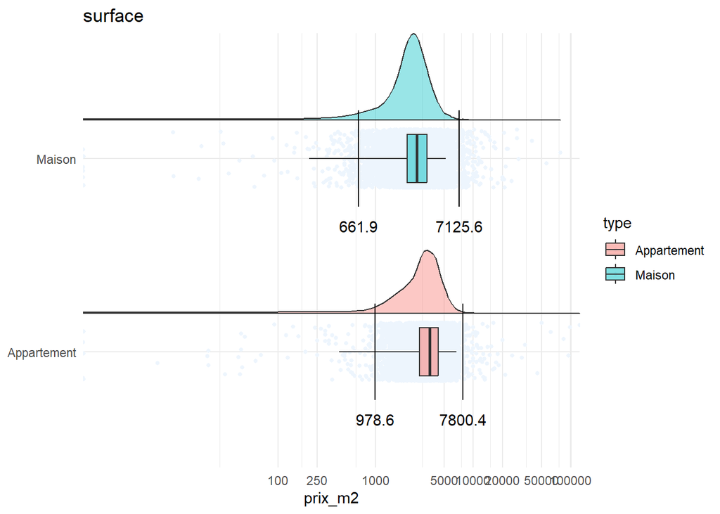

```r
plot <- vente_roch_filter %>%
  select(prix_m2, type) %>%
  ggplot(aes(x = type, y = prix_m2, fill = type)) +
  theme_minimal() +
  PupillometryR::geom_flat_violin(
    position = position_nudge(x = .2),
    alpha = .4,
    show.legend = FALSE
  ) +
  geom_point(
    color = "#edf5fd",
    position = position_jitter(w = .15),
    size = 1,
    show.legend = TRUE
  ) +
  geom_boxplot(
    width = .25,
    outlier.shape = NA,
    alpha = 0.5
  ) +
  geom_segment(
    x = 0.75,
    xend = 1.25,
    y = as.numeric(lim_prix_m2[lim_prix_m2$type == "Appartement", "pct_high"]),
    yend = as.numeric(lim_prix_m2[lim_prix_m2$type == "Appartement", "pct_high"])
  ) +
  annotate(
    "text",
    x = 0.65,
    y = as.numeric(lim_prix_m2[lim_prix_m2$type == "Appartement", "pct_high"]),
    label = paste(round(as.numeric(lim_prix_m2[lim_prix_m2$type == "Appartement", "pct_high"]), 1))
  ) +
  geom_segment(
    x = 0.75,
    xend = 1.25,
    y = as.numeric(lim_prix_m2[lim_prix_m2$type == "Appartement", "pct_low"]),
    yend = as.numeric(lim_prix_m2[lim_prix_m2$type == "Appartement", "pct_low"])
  ) +
  annotate(
    "text",
    x = 0.65,
    y = as.numeric(lim_prix_m2[lim_prix_m2$type == "Appartement", "pct_low"]),
    label = paste(round(as.numeric(lim_prix_m2[lim_prix_m2$type == "Appartement", "pct_low"]), 1))
  ) +
  geom_segment(
    x = 1.75,
    xend = 2.25,
    y = as.numeric(lim_prix_m2[lim_prix_m2$type == "Maison", "pct_high"]),
    yend = as.numeric(lim_prix_m2[lim_prix_m2$type == "Maison", "pct_high"])
  ) +
  annotate(
    "text",
    x = 1.65,
    y = as.numeric(lim_prix_m2[lim_prix_m2$type == "Maison", "pct_high"]),
    label = paste(round(as.numeric(lim_prix_m2[lim_prix_m2$type == "Maison", "pct_high"]), 1))
  ) +
  geom_segment(
    x = 1.75,
    xend = 2.25,
    y = as.numeric(lim_prix_m2[lim_prix_m2$type == "Maison", "pct_low"]),
    yend = as.numeric(lim_prix_m2[lim_prix_m2$type == "Maison", "pct_low"])
  ) +
  annotate(
    "text",
    x = 1.65,
    y = as.numeric(lim_prix_m2[lim_prix_m2$type == "Maison", "pct_low"]),
    label = paste(round(as.numeric(lim_prix_m2[lim_prix_m2$type == "Maison", "pct_low"]), 1))
  ) +
  scale_y_continuous(
    breaks = c(0, 100, 250, 1000, 5000, 10000, 20000, 50000, 100000),
    expand = c(0, 0)
  ) +
  coord_trans_flip(
    y = scales::pseudo_log_trans(base = 2)
  ) +
  labs(
    title = paste(tp),
    x = NULL,
    y = "prix_m2"
  )

# TODO: mettre des breaks potables
print(plot)
```

Pour les mêmes raisons que précédemment, on utilise les seuils identifiés à l’aide des percentiles.

```r
vente_roch_filter_2 <- vente_roch_filter %>%
  filter(
    case_when(
      type == "Appartement" ~ between(
        prix_m2,
        as.numeric(lim_prix_m2[1, "pct_low"]),
        as.numeric(lim_prix_m2[1, "pct_high"])
      )
    ) |
      case_when(
        type == "Maison" ~ between(
          prix_m2,
          as.numeric(lim_prix_m2[2, "pct_low"]),
          as.numeric(lim_prix_m2[2, "pct_high"])
        )
      )
  )
```

526 individus ont été filtrés.

#### 1.4.3.4 Extraction de l’année à partir de la date

```r
vente_roch_filter_2 <- vente_roch_filter_2 %>%
  mutate(
    date = as.Date(date),
    annee = year(date)
  )
```

## 1.5 Exporter le jeu de données

```r
head(vente_roch_filter_2)
```

```
# A tibble: 6 × 13
# Groups:   id_vente [6]
  id_vente   date       type  nature codecommune   prix surface piece siren_epci
  <chr>      <date>     <chr> <chr>  <chr>        <dbl>   <int> <int> <chr>
1 2014-1573… 2014-01-13 Mais… Vente  17003       245800     130     4 200041614
2 2014-1573… 2014-01-25 Mais… Vente  17003       190000     145     6 200041614
3 2014-1574… 2014-01-29 Mais… Vente  17003       140000      74     4 200041614
4 2014-1574… 2014-02-07 Mais… Vente  17003       180000      97     6 200041614
5 2014-1574… 2014-01-31 Mais… Vente  17003       190000      85     3 200041614
6 2014-1576… 2014-02-27 Mais… Vente  17003       250000     142     5 200041614
# ℹ 4 more variables: latitude <dbl>, longitude <dbl>, prix_m2 <dbl>,
#   annee <dbl>
```

```r
write.csv(
  vente_roch_filter_2,
  "data/dvf_rochelle.csv",
  quote = FALSE,
  row.names = FALSE
)
```

## 1.6 Diagnostic des types de mutations

### 1.6.1 Calcul du nombre de mutations

```r
length(unique(merge_vente_roch$id.x))
```

```
[1] 27513
```

### 1.6.2 Nombre de mutations multiventes

```r
MutationsComplexes <- nbunique %>% filter(nb > 1)
length(unique(MutationsComplexes$id.x))
```

```
[1] 1215
```

### 1.6.3 Nombre de mutations monoventes/monolignes

```r
uniquesimple <- merge_vente_roch %>%
  group_by(id.x) %>%
  summarise(
    prix = first(prix),
    surface = first(surface),
    nb = n()
  )

nbtransactionssimplemonoligne <- uniquesimple %>% filter(nb == 1)
length(unique(nbtransactionssimplemonoligne$id.x))
```

```
[1] 25446
```

### 1.6.4 Nombre de mutations monoventes/multilignes

```r
a <- length(unique(merge_vente_roch$id.x))
b <- length(unique(nbtransactionssimplemonoligne$id.x))
a - b
```

```
[1] 2067
```

### 1.6.5 Diagnostic du nombre de biens par mutation

```r
diag_group <- nbunique %>%
  mutate(as.character(nb)) %>%
  group_by(nb) %>%
  summarise(tot = n())
print(diag_group)
```

```
# A tibble: 18 × 2
      nb   tot
   <int> <int>
 1     1 26298
 2     2   915
 3     3   147
 4     4    62
 5     5    25
 6     6    27
 7     7     8
 8     8     8
 9     9     9
10    10     2
11    11     5
12    14     1
13    15     1
14    16     1
15    19     1
16    21     1
17    24     1
18    35     1
```

### 1.6.6 Nombre de mutations multiventes, nombre total et nombre moyen de biens associés

```r
length(MutationsComplexes$id.x)
```

```
[1] 1215
```

```r
sum(MutationsComplexes$nb)
```

```
[1] 3226
```

```r
mean(MutationsComplexes$nb)
```

```
[1] 2.655144
```